```python
import tensorflow as tf
print(tf.__version__)
```

```
2.0.0
```

# Saving and loading models

## Coding tutorials

#### 1. Saving and loading model weights

#### 2. Model saving criteria

#### 3. Saving the entire model

#### 4. Loading pre-trained Keras models

#### 5. Tensorflow Hub modules

## Saving and loading model weights

#### Load and inspect CIFAR-10 dataset

The CIFAR-10 dataset consists of, in total, 60000 color images, each with one of 10 labels: airplane, automobile, bird, cat, deer, dog, frog, horse, ship, truck. For an introduction and a download, see [this link](https://www.cs.toronto.edu/~kriz/cifar.html).

```python
# Import the CIFAR-10 dataset and rescale the pixel values

(x_train, y_train), (x_test, y_test) = tf.keras.datasets.cifar10.load_data()
x_train = x_train / 255.0
x_test = x_test / 255.0

# Use smaller subset -- speeds things up
x_train = x_train[:10000]
y_train = y_train[:10000]
x_test = x_test[:1000]
y_test = y_test[:1000]
```

```python
# Plot the first 10 CIFAR-10 images
#### Rune twice to get the imgs

import matplotlib.pyplot as plt

fig, ax = plt.subplots(1, 10, figsize=(10, 1))
for i in range(10):
    ax[i].set_axis_off()
    ax[i].imshow(x_train[i])
```

[output not shown]

#### Introduce two useful functions

```python
# Introduce function to test model accuracy

def get_test_accuracy(model, x_test, y_test):
    test_loss, test_acc = model.evaluate(x=x_test, y=y_test, verbose=0)
    print('accuracy: {acc:0.3f}'.format(acc=test_acc))
```

```python
# Introduce function that creates a new instance of a simple CNN

from tensorflow.keras.models import Sequential
from tensorflow.keras.layers import Dense, Flatten, Conv2D, MaxPooling2D

def get_new_model():
    model = Sequential([
        Conv2D(filters=16, input_shape=(32, 32, 3), kernel_size=(3, 3),
               activation='relu', name='conv_1'),
        Conv2D(filters=8, kernel_size=(3, 3), activation='relu', name='conv_2'),
        MaxPooling2D(pool_size=(4, 4), name='pool_1'),
        Flatten(name='flatten'),
        Dense(units=32, activation='relu', name='dense_1'),
        Dense(units=10, activation='softmax', name='dense_2')
    ])
    model.compile(optimizer='adam',
                  loss='sparse_categorical_crossentropy',
                  metrics=['accuracy'])
    return model
```

#### Create simple convolutional neural network classifier

```python
# Create an instance of the model and show model summary

model= get_new_model()
model.summary()
```

```
Model: "sequential"
_________________________________________________________________
Layer (type)                 Output Shape              Param #
=================================================================
conv_1 (Conv2D)              (None, 30, 30, 16)        448
_________________________________________________________________
conv_2 (Conv2D)              (None, 28, 28, 8)         1160
_________________________________________________________________
pool_1 (MaxPooling2D)        (None, 7, 7, 8)           0
_________________________________________________________________
flatten (Flatten)            (None, 392)               0
_________________________________________________________________
dense_1 (Dense)              (None, 32)                12576
_________________________________________________________________
dense_2 (Dense)              (None, 10)                330
=================================================================
Total params: 14,514
Trainable params: 14,514
Non-trainable params: 0
_________________________________________________________________
```

```python
# Test accuracy of the untrained model, around 10% (random)

get_test_accuracy(model, x_test, y_test)
```

```
accuracy: 0.097
```

#### Train model with checkpoints

```python
from tensorflow.keras.callbacks import ModelCheckpoint
```

```python
# Create Tensorflow checkpoint object

checkpoint_path = 'model_checkpoints/checkpoint'
checkpoint= ModelCheckpoint(filepath= checkpoint_path,
                           frequency = 'epoch',
                           save_weights_only= True,
                           verbose = 1)
```

```python
# Fit model, with simple checkpoint which saves (and overwrites) model weights every epoch

model.fit(x= x_train, y = y_train, epochs = 3, callbacks = [checkpoint])
```

```
Train on 10000 samples
Epoch 00001: saving model to model_checkpoints/checkpoint
Epoch 00002: saving model to model_checkpoints/checkpoint
Epoch 00003: saving model to model_checkpoints/checkpoint
```

```
<tensorflow.python.keras.callbacks.History at 0x7fb230701240>
```

```python
# Have a look at what the checkpoint creates

! ls -lh model_checkpoints
```

```
total 184K
-rw-r--r-- 1 jovyan users   77 Jun 21 18:05 checkpoint
-rw-r--r-- 1 jovyan users 174K Jun 21 18:05 checkpoint.data-00000-of-00001
-rw-r--r-- 1 jovyan users 2.0K Jun 21 18:05 checkpoint.index
```

```python
# Evaluate the performance of the trained model

get_test_accuracy(model, x_test, y_test)
```

```
accuracy: 0.509
```

#### Create new model, load weights

```python
# Create a new instance of the (initialised) model, accuracy around 10% again

model= get_new_model()
get_test_accuracy(model, x_test, y_test)
```

```
accuracy: 0.103
```

```python
# Load weights -- accuracy is the same as the trained model

model.load_weights(checkpoint_path)
get_test_accuracy(model, x_test, y_test) # this brings the old version
```

```
accuracy: 0.509
```

#### Clear directory

```python
! rm -r model_checkpoints
```

## Model saving criteria

#### Create more customised checkpoint

```python
from tensorflow.keras.callbacks import ModelCheckpoint
```

```python
# Create Tensorflow checkpoint object with epoch and batch details for every 5K sample

checkpoint_5000_path = \
    'model_checkpoints_5000/checkpoint_{epoch:02d}_{batch:04d}'

checkpoint_5000 = ModelCheckpoint(filepath=checkpoint_5000_path,
                                 save_weights_only= True,
                                 save_freq= 5000,
                                 verbose =1)

## with validation cannot save the best only ??
```

```python
# Create and fit model with checkpoint

model = get_new_model()

model.fit(x_train,
          y_train,
          epochs =3,
          validation_data = (x_test, y_test),
          batch_size = 10,
          callbacks=[checkpoint_5000])
```

```
Train on 10000 samples, validate on 1000 samples
Epoch 00001: saving model to model_checkpoints_5000/checkpoint_01_0499
Epoch 00001: saving model to model_checkpoints_5000/checkpoint_01_0999
Epoch 00002: saving model to model_checkpoints_5000/checkpoint_02_0499
Epoch 00002: saving model to model_checkpoints_5000/checkpoint_02_0999
Epoch 00003: saving model to model_checkpoints_5000/checkpoint_03_0499
Epoch 00003: saving model to model_checkpoints_5000/checkpoint_03_0999
```

```
<tensorflow.python.keras.callbacks.History at 0x7f2e79e14eb8>
```

```python
# Have a look at what the checkpoint creates

! ls -lh model_checkpoints_5000
```

```
total 1.1M
-rw-r--r-- 1 jovyan users   93 Jun 21 16:29 checkpoint
-rw-r--r-- 1 jovyan users 174K Jun 21 16:27 checkpoint_01_0499.data-00000-of-00001
-rw-r--r-- 1 jovyan users 2.0K Jun 21 16:27 checkpoint_01_0499.index
-rw-r--r-- 1 jovyan users 174K Jun 21 16:27 checkpoint_01_0999.data-00000-of-00001
-rw-r--r-- 1 jovyan users 2.0K Jun 21 16:27 checkpoint_01_0999.index
-rw-r--r-- 1 jovyan users 174K Jun 21 16:28 checkpoint_02_0499.data-00000-of-00001
-rw-r--r-- 1 jovyan users 2.0K Jun 21 16:28 checkpoint_02_0499.index
-rw-r--r-- 1 jovyan users 174K Jun 21 16:28 checkpoint_02_0999.data-00000-of-00001
-rw-r--r-- 1 jovyan users 2.0K Jun 21 16:28 checkpoint_02_0999.index
-rw-r--r-- 1 jovyan users 174K Jun 21 16:29 checkpoint_03_0499.data-00000-of-00001
-rw-r--r-- 1 jovyan users 2.0K Jun 21 16:29 checkpoint_03_0499.index
-rw-r--r-- 1 jovyan users 174K Jun 21 16:29 checkpoint_03_0999.data-00000-of-00001
-rw-r--r-- 1 jovyan users 2.0K Jun 21 16:29 checkpoint_03_0999.index
```

#### Work with model saving criteria

```python
# Use tiny training and test set -- will overfit!

x_train = x_train[:100]
y_train = y_train[:100]
x_test = x_test[:100]
y_test = y_test[:100]

# this will overfit for sure: so save only the best@!
```

```python
# Create a new instance of untrained model

model = get_new_model()
```

```python
# Create Tensorflow checkpoint object which monitors the validation accuracy

checkpoint_best_path = 'model_checkpoints_best/checkpoint'
checkpoint_best = ModelCheckpoint(filepath=checkpoint_best_path,
                                 save_weights_only=True,
                                 save_freq= 'epoch',
                                 monitor= 'val_accuracy',
                                 save_best_only= True, # like this i should use best_only with MONITOR
                                 verbose =1)
```

```python
# Fit the model and save only the weights with the highest validation accuracy

history = model.fit(x_train,
                    y_train,
                   epochs=50,
                   validation_data=(x_test, y_test),
                   batch_size =10,
                   callbacks= [checkpoint_best],
                   verbose = 0)
```

```
WARNING:tensorflow:Unresolved object in checkpoint: (root).optimizer.iter
WARNING:tensorflow:Unresolved object in checkpoint: (root).optimizer.beta_1
WARNING:tensorflow:Unresolved object in checkpoint: (root).optimizer.beta_2
WARNING:tensorflow:Unresolved object in checkpoint: (root).optimizer.decay
WARNING:tensorflow:Unresolved object in checkpoint: (root).optimizer.learning_rate
WARNING:tensorflow:A checkpoint was restored (e.g. tf.train.Checkpoint.restore or tf.keras.Model.load_weights) but not all checkpointed values were used. See above for specific issues. Use expect_partial() on the load status object, e.g. tf.train.Checkpoint.restore(...).expect_partial(), to silence …

Epoch 00001: val_accuracy improved from -inf to 0.06000, saving model to model_checkpoints_best/checkpoint

Epoch 00002: val_accuracy did not improve from 0.06000

Epoch 00003: val_accuracy did not improve from 0.06000

Epoch 00004: val_accuracy did not improve from 0.06000

Epoch 00005: val_accuracy did not improve from 0.06000

Epoch 00006: val_accuracy did not improve from 0.06000

Epoch 00007: val_accuracy did not improve from 0.06000

Epoch 00008: val_accuracy did not improve from 0.06000

Epoch 00009: val_accuracy improved from 0.06000 to 0.08000, saving model to model_checkpoints_best/checkpoint

Epoch 00010: val_accuracy did not improve from 0.08000

Epoch 00011: val_accuracy improved from 0.08000 to 0.10000, saving model to model_checkpoints_best/checkpoint

Epoch 00012: val_accuracy did not improve from 0.10000

Epoch 00013: val_accuracy improved from 0.10000 to 0.14000, saving model to model_checkpoints_best/checkpoint

Epoch 00014: val_accuracy did not improve from 0.14000

Epoch 00015: val_accuracy did not improve from 0.14000

Epoch 00016: val_accuracy did not improve from 0.14000

Epoch 00017: val_accuracy did not improve from 0.14000
```

[output cut: 51 more lines]

```
Epoch 00043: val_accuracy did not improve from 0.19000

Epoch 00044: val_accuracy improved from 0.19000 to 0.20000, saving model to model_checkpoints_best/checkpoint

Epoch 00045: val_accuracy did not improve from 0.20000

Epoch 00046: val_accuracy did not improve from 0.20000

Epoch 00047: val_accuracy did not improve from 0.20000

Epoch 00048: val_accuracy did not improve from 0.20000

Epoch 00049: val_accuracy did not improve from 0.20000

Epoch 00050: val_accuracy did not improve from 0.20000
```

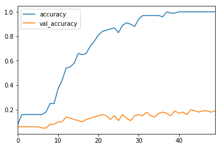

```python
# Plot training and testing curves

import pandas as pd

df = pd.DataFrame(history.history)
df.plot(y=['accuracy', 'val_accuracy'])
```

```python
# Inspect the checkpoint directory

! ls -lh model_checkpoints_best
```

```
total 184K
-rw-r--r-- 1 jovyan users   77 Jun 21 18:06 checkpoint
-rw-r--r-- 1 jovyan users 174K Jun 21 18:06 checkpoint.data-00000-of-00001
-rw-r--r-- 1 jovyan users 2.0K Jun 21 18:06 checkpoint.index
```

```python
# Create a new model with the saved weights

new_model = get_new_model()
new_model.load_weights(checkpoint_best_path)
get_test_accuracy(new_model, x_test, y_test)
```

```
accuracy: 0.200
```

#### Clear directory

```python
! rm -r model_checkpoints_5000 model_checkpoints_best
```

## Saving the entire model

#### Create checkpoint that saves whole model, not just weights

```python
from tensorflow.keras.callbacks import ModelCheckpoint
```

```python
# Create Tensorflow checkpoint object

checkpoint_path = 'model_checkpoints'
checkpoint = ModelCheckpoint(filepath = checkpoint_path,
                            save_weights_only = False,
                            frequency = 'epoch',
                            verbose = 1)
```

```python
# Create and fit model with checkpoint

model = get_new_model()
model.fit(x_train, y_train,
          epochs = 3,
          callbacks = [checkpoint])
```

```
Train on 100 samples
Epoch 00001: saving model to model_checkpoints
WARNING:tensorflow:From /opt/conda/lib/python3.7/site-packages/tensorflow_core/python/ops/resource_variable_ops.py:1781: calling BaseResourceVariable.__init__ (from tensorflow.python.ops.resource_variable_ops) with constraint is deprecated and will be removed in a future version.
Instructions for updating:
If using Keras pass *_constraint arguments to layers.
INFO:tensorflow:Assets written to: model_checkpoints/assets
Epoch 00002: saving model to model_checkpoints
INFO:tensorflow:Assets written to: model_checkpoints/assets
Epoch 00003: saving model to model_checkpoints
INFO:tensorflow:Assets written to: model_checkpoints/assets
```

```
<tensorflow.python.keras.callbacks.History at 0x7fb2cef8b4a8>
```

#### Inspect what the checkpoint has created

```python
# Have a look at what the checkpoint creates

! ls -lh model_checkpoints
```

```
total 128K
drwxr-xr-x 2 jovyan users 6.0K Jun 21 18:14 assets
-rw-r--r-- 1 jovyan users 119K Jun 21 18:14 saved_model.pb
drwxr-xr-x 2 jovyan users 6.0K Jun 21 18:14 variables
```

```python
# Enter variables directory

! ls -lh model_checkpoints/variables
```

```
total 184K
-rw-r--r-- 1 jovyan users 177K Jun 21 18:14 variables.data-00000-of-00001
-rw-r--r-- 1 jovyan users 2.1K Jun 21 18:14 variables.index
```

```python
# Get the model's test accuracy

get_test_accuracy(model, x_test, y_test)
```

```
accuracy: 0.100
```

#### Create new model from scratch

```python
# Delete model

del model
```

```python
from tensorflow.keras.models import load_model
```

```python
# Reload model from scratch

model = load_model(checkpoint_path)
get_test_accuracy(model, x_test, y_test)
```

```
accuracy: 0.100
```

#### Use the .h5 format to save model

```python
# Save the model in .h5 format

model.save('my_model.h5')
```

```python
# Inspect .h5 file

!ls -lh my_model.h5
```

```
-rw-r--r-- 1 jovyan users 77K Jun 21 18:16 my_model.h5
```

```python
# Delete model

del model
```

```python
# Reload model from scratch

model = load_model('my_model.h5')
get_test_accuracy(model, x_test, y_test)
```

```
accuracy: 0.100
```

#### Clear directory

```python
! rm -r model_checkpoints
! rm my_model.h5
```

## Loading pre-trained Keras models

#### Import and build Keras ResNet50 model

Today we'll be using the ResNet50 model designed by a team at Microsoft Research, available through Keras applications. Please see the description on the [Keras applications page](https://keras.io/applications/#resnet) for details. If you continue using it, please cite it properly! The paper it comes from is:

Kaiming He, Xiangyu Zhang, Shaoqing Ren, Jian Sun. "Deep Residual Learning for Image Recognition", 2015.

This model takes a long time to download on the Coursera platform, so it is pre-downloaded in your workspace and saved in Keras HDF5 format. If you want to import it on your personal machine, use the following code:

```
from tensorflow.keras.applications import ResNet50
model = ResNet50(weights='imagenet')
```

In this coding tutorial, you will instead load the model directly from disk.

```python
from tensorflow.keras.models import load_model
```

```python
# Build Keras ResNet50 model

#from keras.applications import ResNet50
model = load_model('models/Keras_ResNet50.h5')
model.summary()

## the final node with 1000 parameter is for 1000 classifications
```

```
WARNING:tensorflow:No training configuration found in save file: the model was *not* compiled. Compile it manually.
Model: "resnet50"
__________________________________________________________________________________________________
Layer (type)                    Output Shape         Param #     Connected to
==================================================================================================
input_1 (InputLayer)            [(None, 224, 224, 3) 0
__________________________________________________________________________________________________
conv1_pad (ZeroPadding2D)       (None, 230, 230, 3)  0           input_1[0][0]
__________________________________________________________________________________________________
conv1_conv (Conv2D)             (None, 112, 112, 64) 9472        conv1_pad[0][0]
__________________________________________________________________________________________________
conv1_bn (BatchNormalization)   (None, 112, 112, 64) 256         conv1_conv[0][0]
__________________________________________________________________________________________________
conv1_relu (Activation)         (None, 112, 112, 64) 0           conv1_bn[0][0]
__________________________________________________________________________________________________
pool1_pad (ZeroPadding2D)       (None, 114, 114, 64) 0           conv1_relu[0][0]
__________________________________________________________________________________________________
pool1_pool (MaxPooling2D)       (None, 56, 56, 64)   0           pool1_pad[0][0]
__________________________________________________________________________________________________
conv2_block1_1_conv (Conv2D)    (None, 56, 56, 64)   4160        pool1_pool[0][0]
__________________________________________________________________________________________________
conv2_block1_1_bn (BatchNormali (None, 56, 56, 64)   256         conv2_block1_1_conv[0][0]
__________________________________________________________________________________________________
conv2_block1_1_relu (Activation (None, 56, 56, 64)   0           conv2_block1_1_bn[0][0]
__________________________________________________________________________________________________
conv2_block1_2_conv (Conv2D)    (None, 56, 56, 64)   36928       conv2_block1_1_relu[0][0]
__________________________________________________________________________________________________
conv2_block1_2_bn (BatchNormali (None, 56, 56, 64)   256         conv2_block1_2_conv[0][0]
__________________________________________________________________________________________________
conv2_block1_2_relu (Activation (None, 56, 56, 64)   0           conv2_block1_2_bn[0][0]
__________________________________________________________________________________________________
conv2_block1_0_conv (Conv2D)    (None, 56, 56, 256)  16640       pool1_pool[0][0]
__________________________________________________________________________________________________
conv2_block1_3_conv (Conv2D)    (None, 56, 56, 256)  16640       conv2_block1_2_relu[0][0]
__________________________________________________________________________________________________
conv2_block1_0_bn (BatchNormali (None, 56, 56, 256)  1024        conv2_block1_0_conv[0][0]
__________________________________________________________________________________________________
conv2_block1_3_bn (BatchNormali (None, 56, 56, 256)  1024        conv2_block1_3_conv[0][0]
__________________________________________________________________________________________________
conv2_block1_add (Add)          (None, 56, 56, 256)  0           conv2_block1_0_bn[0][0]
```

[output cut: 324 more lines]

```
conv5_block3_3_bn (BatchNormali (None, 7, 7, 2048)   8192        conv5_block3_3_conv[0][0]
__________________________________________________________________________________________________
conv5_block3_add (Add)          (None, 7, 7, 2048)   0           conv5_block2_out[0][0]
                                                                 conv5_block3_3_bn[0][0]
__________________________________________________________________________________________________
conv5_block3_out (Activation)   (None, 7, 7, 2048)   0           conv5_block3_add[0][0]
__________________________________________________________________________________________________
avg_pool (GlobalAveragePooling2 (None, 2048)         0           conv5_block3_out[0][0]
__________________________________________________________________________________________________
probs (Dense)                   (None, 1000)         2049000     avg_pool[0][0]
==================================================================================================
Total params: 25,636,712
Trainable params: 25,583,592
Non-trainable params: 53,120
__________________________________________________________________________________________________
```

#### Import and preprocess 3 sample images

```python
# Import 3 sample ImageNet images

from tensorflow.keras.preprocessing.image import load_img

lemon_img = load_img('data/lemon.jpg', target_size=(224, 224))
viaduct_img = load_img('data/viaduct.jpg', target_size=(224, 224))
water_tower_img = load_img('data/water_tower.jpg', target_size=(224, 224))
```

#### Use ResNet50 model to classify images

```python
# Useful function: presents top 5 predictions and probabilities

from tensorflow.keras.preprocessing.image import img_to_array
from tensorflow.keras.applications.resnet50 import preprocess_input, decode_predictions
import numpy as np
import pandas as pd

def get_top_5_predictions(img):
    x = img_to_array(img)[np.newaxis, ...]
    x = preprocess_input(x)
    preds = decode_predictions(model.predict(x), top=5)
    top_preds = pd.DataFrame(columns=['prediction', 'probability'],
                             index=np.arange(5)+1)
    for i in range(5):
        top_preds.loc[i+1, 'prediction'] = preds[0][i][1]
        top_preds.loc[i+1, 'probability'] = preds[0][i][2]
    return top_preds
```

##### Image 1: lemon

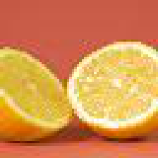

```python
# Display image

lemon_img
```

```python
# Display top 5 predictions

get_top_5_predictions(lemon_img)
```

```
Downloading data from https://storage.googleapis.com/download.tensorflow.org/data/imagenet_class_index.json
```

|  | prediction | probability |
| --- | --- | --- |
| 1 | consomme | 0.227801 |
| 2 | lemon | 0.221758 |
| 3 | eggnog | 0.151335 |
| 4 | ladle | 0.0400883 |
| 5 | spotlight | 0.0291972 |

##### Image 2: viaduct

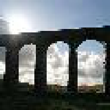

```python
# Display image

viaduct_img
```

```python
# Display top 5 predictions

get_top_5_predictions(viaduct_img)
```

|  | prediction | probability |
| --- | --- | --- |
| 1 | vault | 0.367951 |
| 2 | prison | 0.111742 |
| 3 | viaduct | 0.110738 |
| 4 | window_screen | 0.0882307 |
| 5 | fire_screen | 0.0206752 |

##### Image 3: water tower

[figure not shown]

```python
# Display image

water_tower_img
```

```python
# Display top 5 predictions

get_top_5_predictions(water_tower_img)
```

|  | prediction | probability |
| --- | --- | --- |
| 1 | solar_dish | 0.384681 |
| 2 | ladle | 0.196179 |
| 3 | planetarium | 0.116682 |
| 4 | strainer | 0.04999 |
| 5 | jigsaw_puzzle | 0.0219473 |

## Tensorflow Hub modules

#### Import and build Tensorflow Hub MobileNet v1 model

Today we'll be using Google's MobileNet v1 model, available on Tensorflow Hub. Please see the description on the [Tensorflow Hub page](https://tfhub.dev/google/imagenet/mobilenet_v1_050_160/classification/4) for details on it's architecture, how it's trained, and the reference. If you continue using it, please cite it properly! The paper it comes from is:

Andrew G. Howard, Menglong Zhu, Bo Chen, Dmitry Kalenichenko, Weijun Wang, Tobias Weyand, Marco Andreetto, Hartwig Adam: "MobileNets: Efficient Convolutional Neural Networks for Mobile Vision Applications", 2017.

This model takes a long time to download on the Coursera platform, so it is pre-downloaded in your workspace and saved in Tensorflow SavedModel format. If you want to import it on your personal machine, use the following code:

```
module_url = "https://tfhub.dev/google/imagenet/mobilenet_v1_050_160/classification/4"
model = Sequential([hub.KerasLayer(module_url)])
model.build(input_shape=[None, 160, 160, 3])
```

In this coding tutorial, you will instead load the model directly from disk.

```python
import tensorflow_hub as hub
from tensorflow.keras.models import load_model
```

```python
# Build Google's Mobilenet v1 model

module= load_model('models/Tensorflow_MobileNet_v1')
model = Sequential(hub.KerasLayer(module))
model.build(input_shape= (None, 160, 160, 3))
model.summary()
```

```
Model: "sequential_6"
_________________________________________________________________
Layer (type)                 Output Shape              Param #
=================================================================
keras_layer (KerasLayer)     multiple                  1343049
=================================================================
Total params: 1,343,049
Trainable params: 0
Non-trainable params: 1,343,049
_________________________________________________________________
```

#### Use MobileNet model to classify images

```python
# Import and preprocess 3 sample ImageNet images

from tensorflow.keras.preprocessing.image import load_img

lemon_img = load_img("data/lemon.jpg", target_size=(160, 160)) # must match with the input_shape
viaduct_img = load_img("data/viaduct.jpg", target_size=(160, 160))
water_tower_img = load_img("data/water_tower.jpg", target_size=(160, 160))
```

```python
# Read in categories text file

with open('data/imagenet_categories.txt') as txt_file:
    categories = txt_file.read().splitlines()
```

```python
# Useful function: presents top 5 predictions

import pandas as pd

def get_top_5_predictions(img):
    x = img_to_array(img)[np.newaxis, ...] / 255.0
    preds = model.predict(x)
    top_preds = pd.DataFrame(columns=['prediction'],
                             index=np.arange(5)+1)
    sorted_index = np.argsort(-preds[0])
    for i in range(5):
        ith_pred = categories[sorted_index[i]]
        top_preds.loc[i+1, 'prediction'] = ith_pred

    return top_preds
```

##### Image 1: lemon

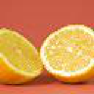

```python
lemon_img
```

```python
get_top_5_predictions(lemon_img)
```

|  | prediction |
| --- | --- |
| 1 | shower cap |
| 2 | tray |
| 3 | candle |
| 4 | brassiere |
| 5 | African chameleon |

##### Image 2: viaduct

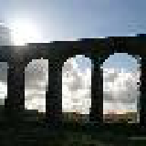

```python
viaduct_img
```

```python
get_top_5_predictions(viaduct_img)
```

|  | prediction |
| --- | --- |
| 1 | viaduct |
| 2 | pier |
| 3 | dam |
| 4 | prison |
| 5 | solar dish |

##### Image 3: water tower

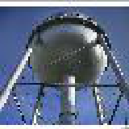

```python
water_tower_img
```

```python
get_top_5_predictions(water_tower_img)
```

|  | prediction |
| --- | --- |
| 1 | solar dish |
| 2 | water tower |
| 3 | aircraft carrier |
| 4 | jigsaw puzzle |
| 5 | oxygen mask |